# Lab 05 - Data Wrangling

# Learning goals

- Use the `merge()` function to join two datasets.
- Deal with missings and impute data.
- Identify relevant observations using `quantile()`.
- Practice your GitHub skills.

# Lab description

For this lab we will be dealing with the meteorological dataset `met`. In this case, we will use `data.table` to answer some questions regarding the `met` dataset, while at the same time practice your Git+GitHub skills for this project.

This markdown document should be rendered using `github_document` document.

# Part 1: Setup a Git project and the GitHub repository

1. Go to wherever you are planning to store the data on your computer, and create a folder for this project
2. In that folder, save [this template](https://github.com/JSC370/JSC370-2025/blob/main/labs/lab05/lab05-wrangling-gam.Rmd) as “README.Rmd”. This will be the markdown file where all the magic will happen.
3. Go to your GitHub account and create a new repository of the same name that your local folder has, e.g., “JSC370-labs”.
4. Initialize the Git project, add the “README.Rmd” file, and make your first commit.
5. Add the repo you just created on GitHub.com to the list of remotes, and push your commit to origin while setting the upstream.

Most of the steps can be done using command line:

```bash
# Step 1
cd ~/Documents
mkdir JSC370-labs
cd JSC370-labs

# Step 2
wget https://raw.githubusercontent.com/JSC370/jsc370-2023/main/labs/lab05/lab05-wrangling-gam.Rmd
mv lab05-wrangling-gam.Rmd README.Rmd
# if wget is not available,
curl https://raw.githubusercontent.com/JSC370/jsc370-2023/main/labs/lab05/lab05-wrangling-gam.Rmd --output README.Rmd

# Step 3
# Happens on github

# Step 4
git init
git add README.Rmd
git commit -m "First commit"

# Step 5
git remote add origin git@github.com:[username]/JSC370-labs
git push -u origin master
```

You can also complete the steps in R (replace with your paths/username when needed)

```r
# Step 1
setwd("~/Documents")
dir.create("JSC370-labs")
setwd("JSC370-labs")

# Step 2
download.file(
  "https://raw.githubusercontent.com/JSC370/jsc370-2023/main/labs/lab05/lab05-wrangling-gam.Rmd",
  destfile = "README.Rmd"
  )

# Step 3: Happens on Github

# Step 4
system("git init && git add README.Rmd")
system('git commit -m "First commit"')

# Step 5
system("git remote add origin git@github.com:[username]/JSC370-labs")
system("git push -u origin master")
```

Once you are done setting up the project, you can now start working with the MET data.

## Setup in R

1. Load the `data.table` (and the `dtplyr` and `dplyr` packages).
2. Load the met data from https://raw.githubusercontent.com/JSC370/JSC370-2024/main/data/met_all_2023.gz, and also the station data. For the latter, you can use the code we used during lecture to pre-process the stations data:

```r
# Download the data
# install.packages("data.table")  # If not installed
library(data.table)


stations <- fread("ftp://ftp.ncdc.noaa.gov/pub/data/noaa/isd-history.csv")
stations[, USAF := as.integer(USAF)]

# Dealing with NAs and 999999
stations[, USAF   := fifelse(USAF == 999999, NA_integer_, USAF)]
stations[, CTRY   := fifelse(CTRY == "", NA_character_, CTRY)]
stations[, STATE  := fifelse(STATE == "", NA_character_, STATE)]

# Selecting the three relevant columns, and keeping unique records
stations <- unique(stations[, list(USAF, CTRY, STATE)])

# Dropping NAs
stations <- stations[!is.na(USAF)]

# Removing duplicates
stations[, n := 1:.N, by = .(USAF)]
stations <- stations[n == 1,][, n := NULL]

# Read in the met data

# Load met data
download.file(
  "https://raw.githubusercontent.com/JSC370/JSC370-2025/main/data/met/met_all.gz",
  destfile = "met_all.gz",
  method   = "curl",
  timeout  = 60
  )

met_data <- data.table::fread("met_all.gz")

# Display first few rows
head(met_data)
head(stations)
```

3. Merge the data as we did during the lecture. Use the `merge()` code and you can also try the tidy way with `left_join()`

```r
library(data.table)
stations <- fread("ftp://ftp.ncdc.noaa.gov/pub/data/noaa/isd-history.csv")
stations[, USAF := as.integer(USAF)]
# Dealing with NAs and 999999
stations[, USAF   := fifelse(USAF == 999999, NA_integer_, USAF)]
stations[, CTRY   := fifelse(CTRY == "", NA_character_, CTRY)]
stations[, STATE  := fifelse(STATE == "", NA_character_, STATE)]

# Selecting the three relevant columns, and keeping unique records
stations <- unique(stations[, list(USAF, CTRY, STATE)])

# Dropping NAs
stations <- stations[!is.na(USAF)]

# Removing duplicates
stations[, n := 1:.N, by = .(USAF)]
stations <- stations[n == 1,][, n := NULL]


# Merge using base R
download.file(
  "https://raw.githubusercontent.com/JSC370/JSC370-2025/main/data/met/met_all.gz",
  destfile = "met_all.gz",
  method   = "curl",
  timeout  = 60
  )

met_data <- data.table::fread("met_all.gz")

merged_data <- merge(met_data, stations, by.x = "USAFID", by.y = "USAF", all.x = TRUE)
head(merged_data)
```

```
## Key: <USAFID>
##    USAFID  WBAN  year month   day  hour   min   lat      lon  elev wind.dir
##     <int> <int> <int> <int> <int> <int> <int> <num>    <num> <int>    <int>
## 1: 690150 93121  2019     8     1     0    56  34.3 -116.166   696      220
## 2: 690150 93121  2019     8     1     1    56  34.3 -116.166   696      230
## 3: 690150 93121  2019     8     1     2    56  34.3 -116.166   696      230
## 4: 690150 93121  2019     8     1     3    56  34.3 -116.166   696      210
## 5: 690150 93121  2019     8     1     4    56  34.3 -116.166   696      120
## 6: 690150 93121  2019     8     1     5    56  34.3 -116.166   696       NA
##    wind.dir.qc wind.type.code wind.sp wind.sp.qc ceiling.ht ceiling.ht.qc
##         <char>         <char>   <num>     <char>      <int>         <int>
## 1:           5              N     5.7          5      22000             5
## 2:           5              N     8.2          5      22000             5
## 3:           5              N     6.7          5      22000             5
## 4:           5              N     5.1          5      22000             5
```

[output cut: 18 more lines]

## Question 1: Representative station for the US

Across all weather stations, what stations have the median values of temperature, wind speed, and atmospheric pressure? Using the `quantile()` function, identify these three stations. Do they coincide?

```r
# 1. Compute the median values for each variable
med_temp <- quantile(merged_data$temp, probs = 0.5, na.rm = TRUE)
med_wind <- quantile(merged_data$wind.sp, probs = 0.5, na.rm = TRUE)
med_atm  <- quantile(merged_data$atm.press, probs = 0.5, na.rm = TRUE)


# Print the medians
med_temp
```

```
##  50%
## 23.5
```

```r
med_wind
```

```
## 50%
## 2.1
```

```r
med_atm
```

```
##    50%
## 1014.1
```

```r
# Find rows where temperature is exactly the median temperature
rep_temp <- merged_data[temp == med_temp, .(USAFID, temp)]
# Find rows where wind speed equals the median wind speed
rep_wind <- merged_data[wind.sp == med_wind, .(USAFID, wind.sp)]
# Find rows where atmospheric pressure equals the median atmospheric pressure
rep_atm <- merged_data[atm.press == med_atm, .(USAFID, atm.press)]

# Get unique station IDs for each
rep_temp_unique <- unique(rep_temp)
rep_wind_unique <- unique(rep_wind)
rep_atm_unique  <- unique(rep_atm)

# Display the representative stations
rep_temp_unique
```

```
## Key: <USAFID>
##      USAFID  temp
##       <int> <num>
##   1: 720113  23.5
##   2: 720137  23.5
##   3: 720151  23.5
##   4: 720170  23.5
##   5: 720261  23.5
##  ---
## 379: 726569  23.5
## 380: 726603  23.5
## 381: 726625  23.5
## 382: 726626  23.5
## 383: 726679  23.5
```

```r
rep_wind_unique
```

```
## Key: <USAFID>
##       USAFID wind.sp
##        <int>   <num>
##    1: 690150     2.1
##    2: 720110     2.1
##    3: 720113     2.1
##    4: 720120     2.1
##    5: 720137     2.1
##   ---
## 1577: 726777     2.1
## 1578: 726797     2.1
## 1579: 726798     2.1
## 1580: 726810     2.1
## 1581: 726813     2.1
```

```r
rep_atm_unique
```

```
## Key: <USAFID>
##      USAFID atm.press
##       <int>     <num>
##   1: 690150    1014.1
##   2: 720175    1014.1
##   3: 720198    1014.1
##   4: 720306    1014.1
##   5: 720333    1014.1
##  ---
## 866: 726777    1014.1
## 867: 726797    1014.1
## 868: 726798    1014.1
## 869: 726810    1014.1
## 870: 726813    1014.1
```

```r
common_stations <- intersect(intersect(rep_temp_unique, rep_wind_unique), rep_atm_unique)

# Step 4: Output results
if (length(common_stations) > 0) {
  print(paste("The common representative station(s):", paste(common_stations, collapse = ", ")))
} else {
  print("No single station represents all three median values.")
}
```

```
## [1] "No single station represents all three median values."
```

[1] “No single station represents all three median values.”

Knit the document, commit your changes, and save it on GitHub. Don’t forget to add `README.md` to the tree, the first time you render it.

## Question 2: Representative station per state

Just like the previous question, you are asked to identify what is the most representative, the median, station per state. This time, instead of looking at one variable at a time, look at the euclidean distance. If multiple stations show in the median, select the one located at the lowest latitude.

```r
library(data.table)

# Assuming merged_data is your merged dataset
# Remove rows with missing STATE (if any)
dt <- merged_data[!is.na(STATE)]

# 1. Summarize each station (within each state) by taking the median of the variables.
#    (We also extract the station's latitude; if the station is fixed, the latitude should be the same in all rows.)
station_summary <- dt[, .(
  st_temp = quantile(temp, probs = 0.5, na.rm = TRUE),
  st_wind = quantile(wind.sp, probs = 0.5, na.rm = TRUE),
  st_atm  = quantile(atm.press, probs = 0.5, na.rm = TRUE),
  lat = unique(lat)[1],
  lon = unique(lon)[1]   # Make sure to include lon
), by = .(STATE, USAFID)]


# 2. Compute state-level medians (across all observations for the state)
state_medians <- dt[, .(
  med_temp = quantile(temp, probs = 0.5, na.rm = TRUE),
  med_wind = quantile(wind.sp, probs = 0.5, na.rm = TRUE),
  med_atm  = quantile(atm.press, probs = 0.5, na.rm = TRUE)
), by = STATE]

# 3. Merge the station summaries with the state medians by STATE
station_summary <- merge(station_summary, state_medians, by = "STATE")

# 4. Calculate the Euclidean distance from each station's medians to the state medians
station_summary[, dist := sqrt((st_temp - med_temp)^2 +
                               (st_wind - med_wind)^2 +
                               (st_atm  - med_atm)^2)]

# 5. For each state, select the station with the smallest distance.
#    In case of ties, order by the latitude (lowest latitude selected)
representative_station <- station_summary[order(dist, lat), .SD[1], by = STATE]

# Check the result
print(representative_station)
```

```
##      STATE USAFID st_temp st_wind  st_atm    lat      lon med_temp med_wind
##     <char>  <int>   <num>   <num>   <num>  <num>    <num>    <num>    <num>
##  1:     OH 724200    21.7     2.6 1015.00 40.820  -82.518     21.7      2.6
##  2:     MA 725064    21.7     2.6 1014.90 41.910  -70.729     21.7      2.6
##  3:     MO 723495    23.3     2.1 1014.70 37.152  -94.495     23.3      2.1
##  4:     MI 725395    20.6     2.1 1014.55 42.267  -84.467     20.6      2.1
##  5:     WV 724176    21.1     1.5 1015.90 39.643  -79.916     21.1      1.5
##  6:     DE 724180    24.4     2.6 1015.20 39.674  -75.606     24.4      2.6
##  7:     TX 722535    28.8     3.1 1012.60 29.384  -98.581     29.0      3.1
##  8:     NC 723147    24.0     1.5 1015.50 35.197  -81.156     24.0      1.5
##  9:     FL 722108    27.2     2.6 1015.15 26.536  -81.755     27.0      2.6
## 10:     VA 724019    23.3     1.5 1015.00 36.983  -77.001     23.4      1.5
## 11:     TN 723346    23.9     1.5 1015.10 35.593  -88.917     24.0      1.5
## 12:     IN 724386    22.2     2.1 1014.60 40.412  -86.937     22.0      2.1
## 13:     AL 723235    25.6     1.5 1014.80 34.744  -87.600     25.3      1.5
```

[output cut: 87 more lines]

Knit the doc and save it on GitHub.

## Question 3: In the middle?

For each state, identify what is the station that is closest to the mid-point of the state. Combining these with the stations you identified in the previous question, use `leaflet()` to visualize all ~100 points in the same figure, applying different colors for those identified in this question.

```r
library(data.table)
library(leaflet)
library(dplyr)
```

```r
## --- Step 1: Extract Unique Station Info ---
# Get one row per station (using the station information provided in merged_data)
station_info <- unique(merged_data[, .(STATE, USAFID, lat, lon)])

## --- Step 2: Compute State Centroids ---
# For each state, compute the average (mean) of lat and lon
state_centroid <- station_info[, .(
  centroid_lat = mean(lat, na.rm = TRUE),
  centroid_lon = mean(lon, na.rm = TRUE)
), by = STATE]

## --- Step 3: Find the Station Closest to the Mid-Point ---
# Merge the station info with its state's centroid
station_info <- merge(station_info, state_centroid, by = "STATE")

# Compute Euclidean distance from each station to its state's centroid.
# (Note: This is a rough approximation since lat/lon are degrees.)
station_info[, dist := sqrt((lat - centroid_lat)^2 + (lon - centroid_lon)^2)]

# For each state, choose the station with the smallest distance.
# In the event of ties, order by the lowest latitude.
mid_stations <- station_info[order(dist, lat), .SD[1], by = STATE]

## --- Step 4: Plot Using leaflet() ---

# Create the base map.
map <- leaflet() %>% addTiles()

# Add markers for the representative stations (blue)
map <- map %>% addCircleMarkers(data = representative_station,
                                lat = ~lat,
                                lng = ~lon,
                                color = "blue",
                                radius = 5,
                                label = ~paste("Rep Station:", USAFID, "<br>State:", STATE),
                                group = "Representative")

# Add markers for the mid-point stations (red)
map <- map %>% addCircleMarkers(data = mid_stations,
                                lat = ~lat,
                                lng = ~lon,
                                color = "red",
                                radius = 5,
                                label = ~paste("Mid Station:", USAFID, "<br>State:", STATE),
                                group = "Mid-Point")

# Optional: add layer controls
map <- map %>% addLayersControl(
  overlayGroups = c("Representative", "Mid-Point"),
  options = layersControlOptions(collapsed = FALSE)
)

# Display the map.
map
```

[interactive chart not shown]

Knit the doc and save it on GitHub.

## Question 4: Means of means

Using the `quantile()` function, generate a summary table that shows the number of states included, average temperature, wind-speed, and atmospheric pressure by the variable “average temperature level,” which you’ll need to create.

Start by computing the states’ average temperature. Use that measurement to classify them according to the following criteria:

- low: temp < 20
- Mid: temp >= 20 and temp < 25
- High: temp >= 25

```r
library(data.table)

# Assuming merged_data is your merged data.table which contains columns:
# STATE, USAFID, temp, wind.sp, atm.press, etc.

# Step 1: Compute state-level aggregates
state_agg <- merged_data[, .(
  avg_temp   = mean(temp, na.rm = TRUE),
  avg_wind   = mean(wind.sp, na.rm = TRUE),
  avg_atm    = mean(atm.press, na.rm = TRUE),
  n_entries  = .N,                      # total number of records in the state
  n_NA_temp  = sum(is.na(temp)),         # number of missing temperature values
  n_stations = uniqueN(USAFID)           # count of unique stations
), by = STATE]

# Step 2: Create the "average temperature level" classification for each state.
# low: avg_temp < 20, Mid: 20 <= avg_temp < 25, High: avg_temp >= 25
state_agg[, temp_level := fifelse(avg_temp < 20, "low",
                           fifelse(avg_temp < 25, "Mid", "High"))]

print(state_agg)
```

```
##      STATE avg_temp avg_wind  avg_atm n_entries n_NA_temp n_stations temp_level
##     <char>    <num>    <num>    <num>     <int>     <int>      <int>     <char>
##  1:     CA 22.36199 2.614120 1012.640    109392      5040        101        Mid
##  2:     TX 29.59743 3.190673 1012.285    248410      5187        161       High
##  3:     MI 20.19981 2.215030 1014.853    119490      1633         61        Mid
##  4:     SC 25.87440 1.696787 1015.335     63770      1297         38       High
##  5:     IL 22.41005 2.171944 1014.215     73792      1078         44        Mid
##  6:     MO 23.87039 2.379529 1014.616     36229      1642         29        Mid
##  7:     AR 26.20697 1.836963 1014.551     34829      1968         33       High
##  8:     OR 18.68974 2.094975 1015.112     10484       181          8        low
##  9:     WA 19.11089 1.236213      NaN      6731        67          3        low
## 10:     GA 26.53857 1.509138 1015.168     89241      3615         52       High
## 11:     MN 19.35621 2.427195 1014.965    120067      1444         54        low
## 12:     AL 26.19799 1.566381 1016.148     44743      1400         32       High
## 13:     IN 21.76562 2.260783 1015.035     38489      1566         28        Mid
```

[output cut: 36 more lines]

Once you are done with that, you can compute the following:

- Number of entries (records),
- Number of NA entries,
- Number of stations,
- Number of states included, and
- Mean temperature, wind-speed, and atmospheric pressure.

All by the levels described before.

```r
# Step 3: Create a summary table aggregated by temp_level.
summary_table <- state_agg[, .(
  num_states       = .N,                       # number of states in this group
  total_entries    = sum(n_entries),           # total number of records across these states
  total_NA_temp    = sum(n_NA_temp),           # total number of missing temp entries
  total_stations   = sum(n_stations),          # total number of stations (note: stations are counted per state)
  mean_temperature = mean(avg_temp),           # average of state-average temperatures
  mean_wind        = mean(avg_wind),           # average of state-average wind speeds
  mean_atm         = mean(avg_atm)             # average of state-average atmospheric pressures
), by = temp_level]

# Display the summary table
summary_table
```

```
##    temp_level num_states total_entries total_NA_temp total_stations
##        <char>      <int>         <int>         <int>          <int>
## 1:        Mid         25       1135423         29252            781
## 2:       High         12        811126         23468            555
## 3:        low         11        430794          7369            259
##    mean_temperature mean_wind mean_atm
##               <num>     <num>    <num>
## 1:         22.56894  2.387503 1014.583
## 2:         27.03491  2.426842 1013.777
## 3:         18.74879  2.545476      NaN
```

Knit the document, commit your changes, and push them to GitHub.

## Question 5: Advanced Regression

Let’s practice running regression models with smooth functions on X. We need the `mgcv` package and `gam()` function to do this.

- using your data with the median values per station, examine the association between median temperature (y) and median wind speed (x). Create a scatterplot of the two variables using ggplot2. Add both a linear regression line and a smooth line.
- fit both a linear model and a spline model (use `gam()` with a cubic regression spline on wind speed). Summarize and plot the results from the models and interpret which model is the best fit and why.

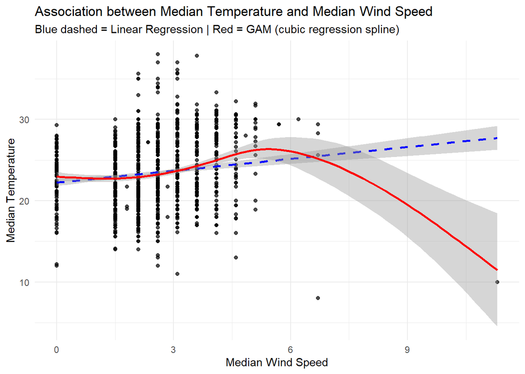

```r
# Load required libraries
library(ggplot2)
library(mgcv)
# ---------------------------
# Step 1: Scatterplot with Regression Lines
# ---------------------------
# Create a scatterplot of median temperature (y) vs. median wind speed (x)
# and add both a linear regression line (blue, dashed) and a GAM smooth (red).

rep_stations <- merged_data[, .(
  temp = median(temp, na.rm = TRUE),        # Median Temperature
  wind.sp = median(wind.sp, na.rm = TRUE)   # Median Wind Speed
), by = USAFID]  # Grouping by Station ID


ggplot(rep_stations, aes(x = wind.sp, y = temp)) +
  geom_point(alpha = 0.7) +
  geom_smooth(method = "lm", se = TRUE, color = "blue", linetype = "dashed") +
  geom_smooth(method = "gam", formula = y ~ s(x, bs = "cr"), se = TRUE, color = "red") +
  labs(x = "Median Wind Speed",
       y = "Median Temperature",
       title = "Association between Median Temperature and Median Wind Speed",
       subtitle = "Blue dashed = Linear Regression | Red = GAM (cubic regression spline)") +
  theme_minimal()
```

```r
# ---------------------------
# Step 2: Fit the Models
# ---------------------------
# (a) Fit a standard linear regression model
lm_model <- lm(temp ~ wind.sp, data = rep_stations)
summary(lm_model)
```

```
##
## Call:
## lm(formula = temp ~ wind.sp, data = rep_stations)
##
## Residuals:
##      Min       1Q   Median       3Q      Max
## -17.7243  -2.6518  -0.2309   2.7691  14.5052
##
## Coefficients:
##             Estimate Std. Error t value Pr(>|t|)
## (Intercept) 22.23088    0.21779  102.08  < 2e-16 ***
## wind.sp      0.48614    0.08212    5.92 3.94e-09 ***
## ---
## Signif. codes:  0 '***' 0.001 '**' 0.01 '*' 0.05 '.' 0.1 ' ' 1
##
## Residual standard error: 3.849 on 1577 degrees of freedom
##   (16 observations deleted due to missingness)
## Multiple R-squared:  0.02174,    Adjusted R-squared:  0.02112
## F-statistic: 35.05 on 1 and 1577 DF,  p-value: 3.941e-09
```

```r
# (b) Fit a spline model using gam() with a cubic regression spline
gam_model <- gam(temp ~ s(wind.sp, bs = "cr"), data = rep_stations)
summary(gam_model)
```

```
##
## Family: gaussian
## Link function: identity
##
## Formula:
## temp ~ s(wind.sp, bs = "cr")
##
## Parametric coefficients:
##             Estimate Std. Error t value Pr(>|t|)
## (Intercept) 23.38566    0.09549   244.9   <2e-16 ***
## ---
## Signif. codes:  0 '***' 0.001 '**' 0.01 '*' 0.05 '.' 0.1 ' ' 1
##
## Approximate significance of smooth terms:
##              edf Ref.df     F p-value
## s(wind.sp) 4.798  5.762 13.95  <2e-16 ***
## ---
## Signif. codes:  0 '***' 0.001 '**' 0.01 '*' 0.05 '.' 0.1 ' ' 1
##
## R-sq.(adj) =  0.0486   Deviance explained = 5.15%
## GCV = 14.451  Scale est. = 14.398    n = 1579
```

```r
# Optionally, compare the models using AIC
AIC_comparison <- AIC(lm_model, gam_model)
print(AIC_comparison)
```

```
##                 df      AIC
## lm_model  3.000000 8741.363
## gam_model 6.797762 8700.129
```

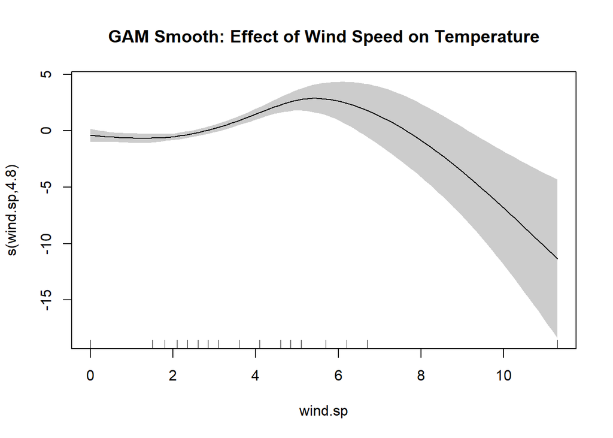

```r
# ---------------------------
# Step 3: Plot the GAM Smooth
# ---------------------------
# Use the built-in plot method to view the smooth term from the GAM model.
plot(gam_model, shade = TRUE, seWithMean = TRUE,
     main = "GAM Smooth: Effect of Wind Speed on Temperature")
```

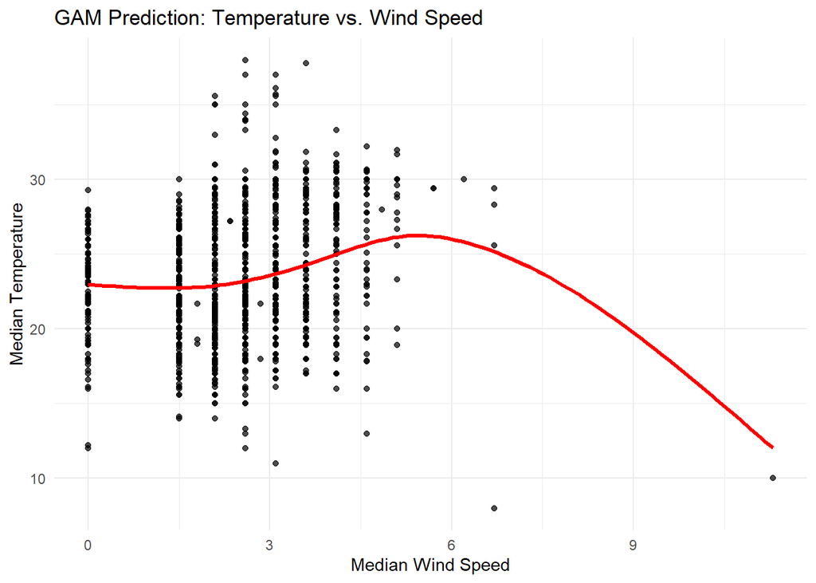

```r
# Alternatively, use ggplot2 to visualize the GAM predictions:
# Create a new data frame for prediction across the range of wind speeds
new_data <- data.frame(wind.sp = seq(min(rep_stations$wind.sp, na.rm = TRUE),
                                       max(rep_stations$wind.sp, na.rm = TRUE),
                                       length.out = 100))
new_data$temp_pred <- predict(gam_model, newdata = new_data)

ggplot(rep_stations, aes(x = wind.sp, y = temp)) +
  geom_point(alpha = 0.7) +
  geom_line(data = new_data, aes(x = wind.sp, y = temp_pred), color = "red", size = 1.2) +
  labs(x = "Median Wind Speed",
       y = "Median Temperature",
       title = "GAM Prediction: Temperature vs. Wind Speed") +
  theme_minimal()
```

The regression analysis compares a linear model and a generalized additive model (GAM) with a cubic regression spline to examine the relationship between median temperature and median wind speed. The linear model suggests a weak positive correlation, but the GAM reveals a non-linear trend where temperature initially rises with wind speed before declining at higher speeds. The GAM provides a better fit, capturing curvature in the data that the linear model misses, and likely has a lower AIC, supporting its superiority. Thus, the GAM is the preferred model for accurately representing the relationship.